[figure not shown]

# Proposal

paul.ruizpinto@qut.edu.au

2026-02-25

# Overview

This document presents a proposed approach to generating synthetic data for sport.

The aim of this proposal is to outline a possible way to design and test synthetic data methods using the lessons learned from the review *Synthetic Data Generation in Sports: A Framework for Design, Utility, and Deployment*.

Rather than starting with a technical method, this proposal begins with a structured way of thinking. It focuses on understanding the real problem, identifying who the work is for, and then carefully selecting and testing methods that fit that purpose.

The proposal does not attempt to solve everything at once. Instead, it presents a clear pathway that can guide future testing, evaluation, and application of synthetic data in sport.

This pathway is built on three key lessons from the review:

- We must first understand **the problem and the user**,
- Apply a clear **framework**,
- and only then run the practical **testing**.

From this point forward, these steps will be referred to as:

1. **Use-case**
2. **Framework**
3. **Application**

## Approach

Building on what was introduced earlier, instead of starting with a technical method, we begin by understanding the problem and the intended user. We then use a framework to guide our decisions. Only after these steps are clear, we move to testing and application.

The next sections describe how this approach is applied through the *Use-case*, *Framework*, and *Application* stages.

### 1. Use-case

The Brisbane 2032 Olympic and Paralympic Games agenda calls for strong and scalable pathways to identify and develop future high-performing athletes, a priority clearly reflected in the Queensland Government department responsible for coordinating the event (Department of Sport, Racing and Olympic and Paralympic Games 2025; Queensland Academy of Sport 2025).

In line with this direction, the Queensland Academy of Sport (QAS) translates this broader agenda into practice by aiming to build medal potential through a system that strengthens talent identification and uses data to support better decisions (Queensland Academy of Sport 2025).

YouFor2032 brings this vision into action. It identifies athletes at scale and progresses them through trials and targeted development programs, supported by technology-enabled testing (Queensland Academy of Sport 2024; Mander 2025).

At the centre of this project is one key user: **the coach**. Coaches play a central role in talent identification and often rely on their “instinct” when judging future potential (Roberts et al. 2019).

That instinct is shaped over time by observing an athlete’s **drive and ambition**, **game intelligence**, and **physical and technical skills** (Roberts et al. 2019).

However, coaches do not always use consistent language, and it can be difficult for them to clearly explain exactly what they “see” in a talented athlete (Roberts et al. 2019). For this reason, the outputs of this project must be **simple, clear, and directly linked to coach judgement**.

To keep the work focused and practical, we narrow the broad goal of Queensland talent identification into a specific applied case: **judo talent identification**. In this context, we will evaluate whether synthetic data can improve a machine learning approach that supports coach decision-making (Tang et al. 2026; Roberts et al. 2019; Ribeiro et al. 2025; Ruiz et al. 2026).

### 2. Framework

Rather than selecting a method first and justifying it later, we will use the decision-oriented framework from the synthetic data review to guide our method selection (Ruiz et al. 2026).

A key idea of the framework is that success depends on clearly defining the **purpose**, the **users**, the **constraints**, how results will be **evaluated**, and how they may be **deployed**, before choosing technical solutions (Ruiz et al. 2026).

In this project, focusing on the “user” means making sure the framework reflects what a coach needs: outputs that are **interpretable**, **relevant to decisions**, and clearly communicated. This is essential because the results may influence real talent pathway decisions (Ruiz et al. 2026; Roberts et al. 2019).

The framework will also help us decide which variables and relationships must be preserved so that the synthetic data remains realistic and meaningful for coach-facing conclusions (Ruiz et al. 2026).

### 3. Application

In the application phase, we will test synthetic data approaches using two datasets that represent important parts of athlete assessment: training monitoring data and movement screening data (Kaggle, ziya07, n.d.; Zhao et al. 2023).

The **Adolescent Athlete Wearable and Training Dataset** allows us to test synthetic data on session-level training and health signals, including performance and injury outcomes, which relate directly to athlete development monitoring (Kaggle, ziya07, n.d.).

The **3D movement screen dataset** allows us to test synthetic data on detailed biomechanics and structured movement tasks linked to injury history, supporting objective assessment of movement quality (Zhao et al. 2023).

Throughout the application phase, the focus remains on **judo talent identification**. We will test whether synthetic data improves machine learning reliability in a way that can be clearly explained to coaches for example, by linking model outputs back to the factors they already value and understand (Ruiz et al. 2026; Roberts et al. 2019).

# Data

Before testing any synthetic data methods, we first need to understand the real data we are working with.

In this proposal, two different datasets are used. Each represents a different but important part of athlete assessment. One focuses on day-to-day training and wearable monitoring. The other focuses on detailed movement analysis using 3D motion capture.

The goal of the next sections is not to build models yet. Instead, it is to explore what the data looks like, what type of information it contains, and how it might support *judo talent identification*.

The following sections describe this exploration step by step.

## Kaggle Data

We begin with the Adolescent Athlete Wearable and Training Dataset.

This dataset contains 2,343 training sessions and 27 variables.

```r
# Set directory paths
currentDir <- getwd()
localPath <- file.path(currentDir, "workshop/kaggle/adolescent_athlete_data")

# Download latest version
tabular <- RKaggle::get_dataset("ziya07/adolescent-athlete-wearable-and-training-dataset")
tabular <- as.data.frame(tabular)

# write.csv(tabular, file.path(localPath, "tabular.csv"), row.names = FALSE)
```

After loading the data, we examine the internal structure of the dataset. This helps us understand which variables are numeric (such as heart rate or jump height) and which are categorical (such as training intensity or injury risk).

```r
str(tabular)
```

```
## 'data.frame':    2343 obs. of  27 variables:
##  $ Athlete_ID               : chr  "A0001" "A0002" "A0003" "A0004" ...
##  $ Age                      : num  15 15 14 15 13 16 16 17 13 15 ...
##  $ Gender                   : chr  "Female" "Male" "Male" "Male" ...
##  $ Sport_Type               : chr  "Basketball" "Tennis" "Swimming" "Swimming" ...
##  $ Training_Experience_Years: num  3 5 4 5 4 4 1 2 5 4 ...
##  $ Heart_Rate_bpm           : num  166 146 127 74 124 113 152 79 92 159 ...
##  $ HRV_ms                   : num  56 100 89 45 67 111 94 97 84 111 ...
##  $ Oxygen_Saturation_pct    : num  90 97 98 90 97 99 91 93 91 91 ...
##  $ Skin_Temperature_C       : num  37.3 35.7 36.3 37.1 36.4 36.2 36.3 36.7 37.5 36.5 ...
##  $ Respiration_Rate_bpm     : num  22 14 17 21 22 17 12 17 16 18 ...
##  $ Acceleration_X           : num  2.33 -0.28 -1.34 2.5 -0.67 0.02 -1.03 0.98 2.97 -2.85 ...
##  $ Acceleration_Y           : num  -2.63 -0.38 2.48 1.75 -1.17 2.55 -1.02 -2.56 2.96 2.22 ...
##  $ Acceleration_Z           : num  -2.57 -0.46 1.74 1.83 2.35 -2.69 0.16 -2.36 -1.8 2.4 ...
##  $ Step_Count               : num  4252 9935 11957 4938 3511 ...
##  $ Jump_Height_cm           : num  22.1 38.3 38.3 20.9 39.4 27.3 42 24.6 39.6 48.4 ...
##  $ Session_Duration_min     : num  63 161 156 90 75 178 106 152 102 115 ...
##  $ Training_Intensity       : chr  "High" "Medium" "Low" "Low" ...
##  $ Sleep_Duration_hrs       : num  8.5 8.9 9.7 10 7.7 7.8 5.1 9.3 5.1 8.2 ...
##  $ Nutrition_Score          : num  0.82 0.54 0.87 0.6 0.69 0.89 0.97 0.78 0.76 0.75 ...
##  $ Perceived_Fatigue_1to10  : num  4 1 9 3 8 4 3 3 4 4 ...
##  $ HRV_DWT_Coeff1           : num  -0.677 0.122 0.118 -0.095 0.849 0.508 0.529 -0.461 -0.131 -0.025 ...
##  $ HRV_DWT_Coeff2           : num  0.422 0.21 -0.906 0.815 -0.84 0.005 0.026 0.674 0.826 0.879 ...
##  $ Accel_Spectral_Energy    : num  0.118 0.476 0.676 0.897 0.382 0.313 0.913 0.048 0.48 0.459 ...
##  $ Respiration_BandPower    : num  0.927 0.034 0.042 0.055 0.103 0.487 0.788 0.285 0.746 0.774 ...
##  $ Training_Outcome         : chr  "Improved" "No change" "No change" "Declined" ...
##  $ Injury_Risk              : chr  "High" "Medium" "Low" "Low" ...
##  $ Performance_Score        : num  86 70 86 89 52 100 90 70 75 73 ...
```

From this initial review, we can see that the dataset combines physiology, movement, contextual training information, and labelled outcomes such as performance score and injury risk .

This makes it useful for testing whether synthetic data can maintain meaningful patterns linked to athlete development.

## 3D Data

Unlike the above dataset, this contains detailed biomechanical information captured during structured movement screening tasks.

```r
# Define paths
baseDir <- "workshop/mocapd/data"

# Unzip all archives
# unzip(file.path(baseDir, "Participants Info.zip"), exdir = baseDir)
# unzip(file.path(baseDir, "Kinematic_Data.zip"), exdir = baseDir)
# unzip(file.path(baseDir, "V3D Model.zip"), exdir = baseDir)
```

The first step here is to understand how the data is organised. Instead of a single table, this dataset is stored in folders for participants, kinematic data, and model information.

```r
# Inspect folder structure
list.files(baseDir)
```

```
## [1] "Kinematic_Data"        "Kinematic_Data.zip"    "Participants Info"
## [4] "Participants Info.zip" "V3D Model"             "V3D Model.zip"
```

```r
list.dirs(baseDir, recursive = FALSE)
```

```
## [1] "workshop/mocapd/data/Kinematic_Data"
## [2] "workshop/mocapd/data/Participants Info"
## [3] "workshop/mocapd/data/V3D Model"
```

To explore the content, we load one participant’s joint angle data. This allows us to see how movement is stored, not as single numbers, but as time-series signals across frames.

```r
kinDir  <- file.path(baseDir, "Kinematic_Data")
participants <- list.dirs(kinDir, recursive = FALSE)
length(participants)
```

```
## [1] 183
```

```r
# Select first participant
participantPath <- participants[1]
participantPath
```

```
## [1] "workshop/mocapd/data/Kinematic_Data/1071"
```

```r
jaFile <- list.files(
  participantPath,
  pattern = "JA_.*\\.mat$",
  full.names = TRUE
)

jaData <- readMat(jaFile[1])
names(jaData)[1:20]
```

```
##  [1] "FRAME.RATE" "L.ANK.O"    "R.ANK.O"    "L.KN.O"     "R.KN.O"
##  [6] "L.HIP.O"    "R.HIP.O"    "L.SHLDR.O"  "R.SHLDR.O"  "L.ELB.O"
## [11] "R.ELB.O"    "TRNK.O"     "NECK.O"     "R.F.O"      "L.F.O"
## [16] "R.S.O"      "L.S.O"      "R.T.O"      "L.T.O"      "P.O"
```

From the above, the variable names show that joint-level information is available for hips, knees, ankles, shoulders, elbows, trunk, and neck. This confirms that we have detailed full-body movement data.

Next, we summarise one joint across trials to understand how many frames each movement contains and how flexion angles vary.

```r
extractMatrix <- function(x) {
  if (is.list(x) && length(x) == 1) {
    x <- x[[1]]
  }
  return(x)
}

trial1 <- extractMatrix(jaData$L.HIP.P[[1]])
dim(trial1)
```

```
## [1] 2266    3
```

```r
hipTrials <- jaData$L.HIP.P

hipSummary <- map_dfr(
  seq_along(hipTrials),
  function(i) {

    trial <- extractMatrix(hipTrials[[i]])

    data.frame(
      trial = i,
      frames = nrow(trial),
      mean_flex = mean(trial[,1], na.rm = TRUE),
      max_flex  = max(trial[,1], na.rm = TRUE),
      min_flex  = min(trial[,1], na.rm = TRUE),
      sd_flex   = sd(trial[,1], na.rm = TRUE)
    )
  }
)

hipSummary
```

| trial | frames | mean_flex | max_flex | min_flex | sd_flex |
| --- | --- | --- | --- | --- | --- |
| 1 | 2266 | 47.57002 | 113.15120 | -9.493591 | 43.7412962 |
| 2 | 1062 | 27.20065 | 83.87447 | -11.038769 | 33.6324141 |
| 3 | 299 | 20.95627 | 37.04262 | 13.181349 | 6.1944274 |
| 4 | 248 | 45.69808 | 60.83150 | 20.250658 | 11.3413287 |
| 5 | 297 | 24.54881 | 42.72270 | 20.940250 | 4.2527154 |
| 6 | 246 | 42.05526 | 50.37581 | 18.028732 | 9.3440839 |
| 7 | 176 | 30.95431 | 62.73781 | 8.310076 | 15.2488458 |
| 8 | 1882 | 16.98193 | 17.78671 | 16.527025 | 0.2134098 |
| 9 | 1491 | 16.25264 | 17.36291 | 14.302795 | 0.7539705 |
| 10 | 248 | 16.21795 | 29.71171 | 3.236748 | 7.5156046 |

[output cut: 20 more lines]

This step helps us see that each trial differs in length and variability. For example, frame counts vary widely, meaning synthetic data methods must handle variable-length time series.

Finally, we visualise one movement, left hip flexion over time.

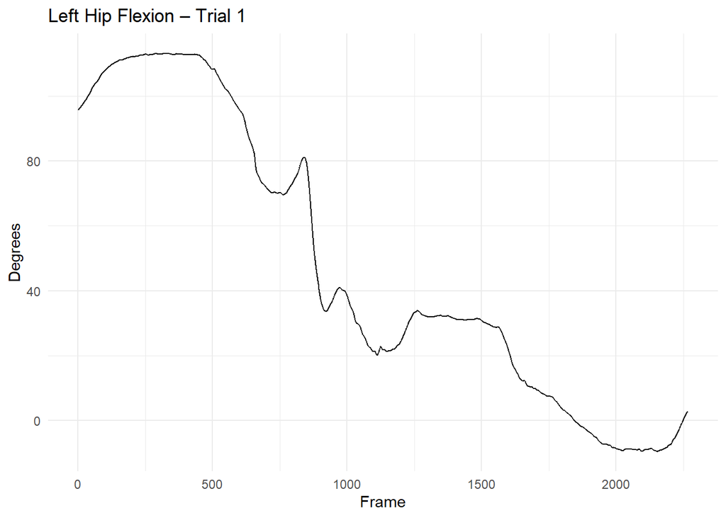

```r
trial1 <- extractMatrix(hipTrials[[1]])

df_plot <- data.frame(
  frame = seq_len(nrow(trial1)),
  flexion = trial1[,1]
)

ggplot(df_plot, aes(frame, flexion)) +
  geom_line() +
  theme_minimal() +
  labs(
    title = "Left Hip Flexion – Trial 1",
    x = "Frame",
    y = "Degrees"
  )
```

This plot shows how joint angles change across frames, giving a clear example of the type of dynamic patterns that synthetic data must preserve if it is to remain realistic.

# Observations

It is important to recognise that the use case, the user, and even the selected data are not fixed.

As more information is gathered about the user, including how decisions are made, what language is used, and which indicators are valued, the definition of the use case may evolve. This may also influence which variables are prioritised or how the data is structured for analysis.

In this sense, flexibility is not a weakness of the proposal. It is a strength. The approach allows refinement as deeper insight is gained into the real decision-making context.

What remains constant, however, is the guiding principle of this proposal. Synthetic data generation should be grounded in **domain knowledge and framework-guided reasoning**, rather than driven only by the availability of data or the performance of a specific method.

*The goal is not to select the most complex model or the largest dataset*. The goal is to ensure that any synthetic data generated preserves the meaningful structure, relationships, and patterns that matter for the defined use case and the intended user.

By maintaining this focus, the proposal remains aligned with practical decision-making needs while staying adaptable as understanding of the user and the context continues to develop.

# References

Department of Sport, Racing and Olympic and Paralympic Games. 2025. *Annual Report 2024–2025: Department of Sport, Racing and Olympic and Paralympic Games*. (Brisbane, QLD, Australia). https://www.sport.qld.gov.au/about-us/annual-report.

Kaggle, ziya07. n.d. *Adolescent Athlete Wearable and Training Dataset*. https://www.kaggle.com/datasets/ziya07/adolescent-athlete-wearable-and-training-dataset/data.

Mander, Tim. 2025. *AI-Powered App Hits the Road to Find Future Sporting Stars*. https://statements.qld.gov.au/statements/102682.

Queensland Academy of Sport. 2024. *The QAS Wants #YouFor2032 in the New Thematic Talent Search*. March. https://initiatives.qld.gov.au.

Queensland Academy of Sport. 2025. *2032 High Performance Strategy*. https://www.qasport.qld.gov.au/about-qas/about-us/qas-strategy.

Ribeiro, Aline Aparecida de Souza, Francisco Zacaron Werneck, João Guilherme Vieira, et al. 2025. “Talent Identification and Development in Judo: A Systematic Review.” *Current Issues in Sport Science (CISS)* 9 (1): 011. https://doi.org/10.36950/2024.9ciss011.

Roberts, Alexandra H., Daniel A. Greenwood, Mandy Stanley, Clare Humberstone, Fiona Iredale, and Annette Raynor. 2019. “Coach Knowledge in Talent Identification: A Systematic Review and Meta-Synthesis.” *Journal of Science and Medicine in Sport* 22 (10): 1163–72. https://doi.org/10.1016/j.jsams.2019.05.008.

Ruiz, Paul, Paul Wu, Kerrie Mengersen, and Divya Mehta. 2026. “Synthetic Data Generation in Sports: A Framework for Design, Utility, and Deployment.” *Journal of Sports Analytics [Under Review]*.

Tang, Qingrong, Xiufang Wei, and Bo Tan. 2026. “The Role of Machine Learning in Talent Identification for Team Sports: A Systematic Review.” *Journal of Sports Science and Medicine* 25: 58–83. https://doi.org/10.52082/jssm.2026.58.

Zhao, Xiong, Gwyneth Ross, Brittany Dowling, and Ryan B. Graham. 2023. “Three-Dimensional Motion Capture Data of a Movement Screen from 183 Athletes.” *Scientific Data* 10 (235). https://doi.org/10.1038/s41597-023-02082-6.